# Module 0: Orientation

#### Figures

##### With default global settings

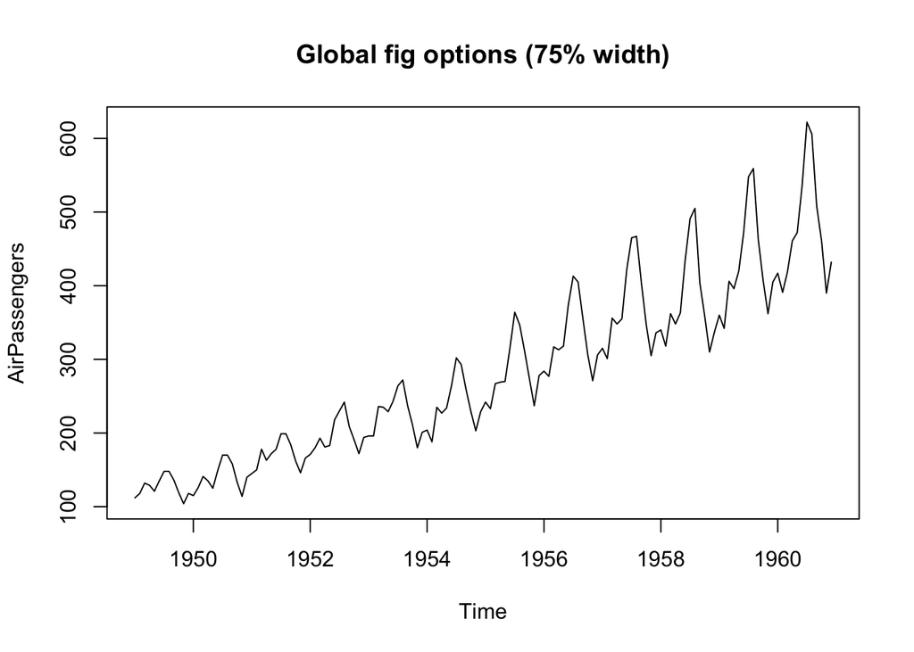

```r
plot(AirPassengers, main = "Global fig options (75% width)")
```

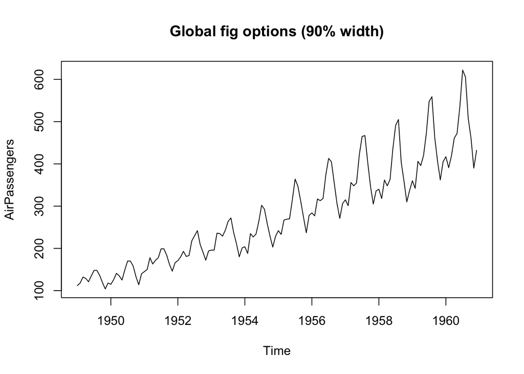

```r
plot(AirPassengers, main = "Global fig options (90% width)")
```

# RStudio Setup with Global Options

**Global Options** are `RStudio’s` application-wide preferences—the settings that control how `RStudio` looks and behaves across all projects and sessions in your environment such as `DataHub`. From here you configure things like the editor’s appearance (font, theme), code editing behavior (indentation, function highlighting, rainbow parentheses), and more. These choices persist between sessions and apply by default to any project you open. This part of the module is going to guide you on how to set up your environment with features that are going to enhance your learning and coding ability.

To access your **Global Options** click **Tools** at the top of your RStudio environment -> click **Global Options**.

## Code

In the left sidebar, click **Code**

### Editing

Then click **Editing** tab at the top In the **General** section, select these options - Insert spaces for Tab (2 spaces is standard for the number of spaces a tab creates)  
- Auto-detect code indentation - Insert matching parentheses/quotes - Vertically align arguments in auto-indent

Here is how your **Editing** tab should look like after completing these steps

[figure not shown]

```r
knitr::include_graphics(here::here(week, "images", "01_code-editing.png"))
```

### Display

Remain in the **Code** pane and click on the **Display** tab

#### General

In the **General** section

Select these options - Highlight selected word - Show line numbers - Show margin and set Margin column to 80 - Highlight selected word - Highlight R function calls (syntax emphasis for function names) - Blinking cursor - Allow drag and drop of text

Here is how your **Display** tab should look like after completing these steps

[figure not shown]

```r
knitr::include_graphics(here(week, "images", "01_code-display.png"))
```

## Appearance

In the left sidebar, click **Appearance**

Set - Editor font: choose a font you like - Editor font size: pick a comfortable size for your code - Help panel font size: pick a comfortable size for the warning & error messages - Editor theme: choose a light or dark theme you prefer

[figure not shown]

```r
knitr::include_graphics(here(week, "images", "01_appearance.png"))
```

Click OK (or Apply then OK) to save all changes. if any appearance changes don’t immediately take effect.Restart your RStudio session